# Homework 2-1

Nithin Mahesh

### Basic Statistics (55 points)

#### Part1: Generating distributions with randomly generated data.

This function generates 10 samples at random from the normal distribution:

```r
rnorm(10)
```

We’ll set the random number generator to generate a set of values based on a seed value:

```r
set.seed(1234)
rnorm(10)
```

These statements demonstrate that the seed “lasts” for one call:

```r
rnorm(10)
set.seed(1234)
rnorm(10)
```

These statements get descriptive statistics with a call to summary and sd- the standard deviation:

```r
data<-rnorm(10)
summary(data)
sd(data)
```

Q1(2pts): Repeat the above three statements with 10000 data points and see if the mean and sd get closer to the ideal of mean=0, SD=1.

```r
data <-rnorm(10000)
summary(data)
```

```
##     Min.  1st Qu.   Median     Mean  3rd Qu.     Max.
## -3.78000 -0.63940  0.01623  0.01561  0.68430  4.08800
```

```r
sd(data)
```

```
## [1] 0.9917101
```

Q2(2pts): Make a function call to rnorm using the parameters mean and sd to generate a normal distribution with 4 data points and a mean=5 and sd=9.

```r
rnorm(4, mean=5, sd=9)
```

```
## [1] -1.964156 -1.457472  4.351414 15.162386
```

```r
data <- rnorm(10000, mean=10, sd=3)
summary(data)
```

```
##    Min. 1st Qu.  Median    Mean 3rd Qu.    Max.
##  -1.332   8.009  10.010  10.040  12.010  22.760
```

```r
sd(data)
```

```
## [1] 2.970081
```

#### Part2: Read data file, plot and calculate descriptive statistics.

Q4(2pts): Read in the Grades.tsv data file with the read.table function and assign the output to the variable “df.grades”.

```r
df.grades<-read.table("Grades.tsv", header = TRUE)
```

Q5(2pts): View the top rows (use the head function).

```r
head(df.grades)
```

```
##   Midterm FinalExam Grade
## 1       0         0     F
## 2      94        89     A
## 3      80        45     D
## 4      86        79     B
## 5      50        24     F
## 6      92        94     A
```

Q6(2pts): Generate the descriptive statistics (with the summary function) for the entire data set.

```r
summary(df.grades)
```

```
##     Midterm         FinalExam      Grade
##  Min.   :  0.00   Min.   :  0.00   A:187
##  1st Qu.: 75.00   1st Qu.: 58.00   B:123
##  Median : 88.00   Median : 80.00   C:110
##  Mean   : 80.22   Mean   : 71.55   D: 52
##  3rd Qu.: 95.00   3rd Qu.: 92.00   F: 48
##  Max.   :100.00   Max.   :100.00
```

Q7(2pts): What is the most common grade?

# The summary stats show us that “A” was the most frequent for exams

Note the two ways you can access a column vector in a data frame: First way: df.grades$Midterm Second way: df.grades[,1]

Q8(2pts): Now generate the descriptive statistics and the standard deviation for only the midterm exam. Use the first way shown above (using the column name) to access this column.

```r
summary(df.grades$Midterm)
```

```
##    Min. 1st Qu.  Median    Mean 3rd Qu.    Max.
##    0.00   75.00   88.00   80.22   95.00  100.00
```

```r
midtermGrades<-df.grades$Midterm
sd(midtermGrades)
```

```
## [1] 22.40716
```

Q9(2pts): Generate the descriptive statistics and the standard deviation for only the final exam. Use the first way shown above (using the column name) to access this column.

```r
summary(df.grades$FinalExam)
```

```
##    Min. 1st Qu.  Median    Mean 3rd Qu.    Max.
##    0.00   58.00   80.00   71.55   92.00  100.00
```

```r
sd(df.grades$FinalExam)
```

```
## [1] 26.47537
```

Q10(2pts): Which distribution has higher scores?

# Looking at the descriptive statistics we can see that midterm has the higher scores than the final exam.

Q11(2pts): Which distribution is more dispersed?

# Since the final exam’s standard deviation is further away from the mean we can see that it is in fact more dispersed.

Q12(5pts): Generate a histogram and a density plot of the midterm distribution. Add vertical lines for the mean and median to the histogram. Make the lines different line types (with the lty parameter).  
You may look here for graphical parameters: http://www.statmethods.net/advgraphs/parameters.html Make both plots appear in the same window.

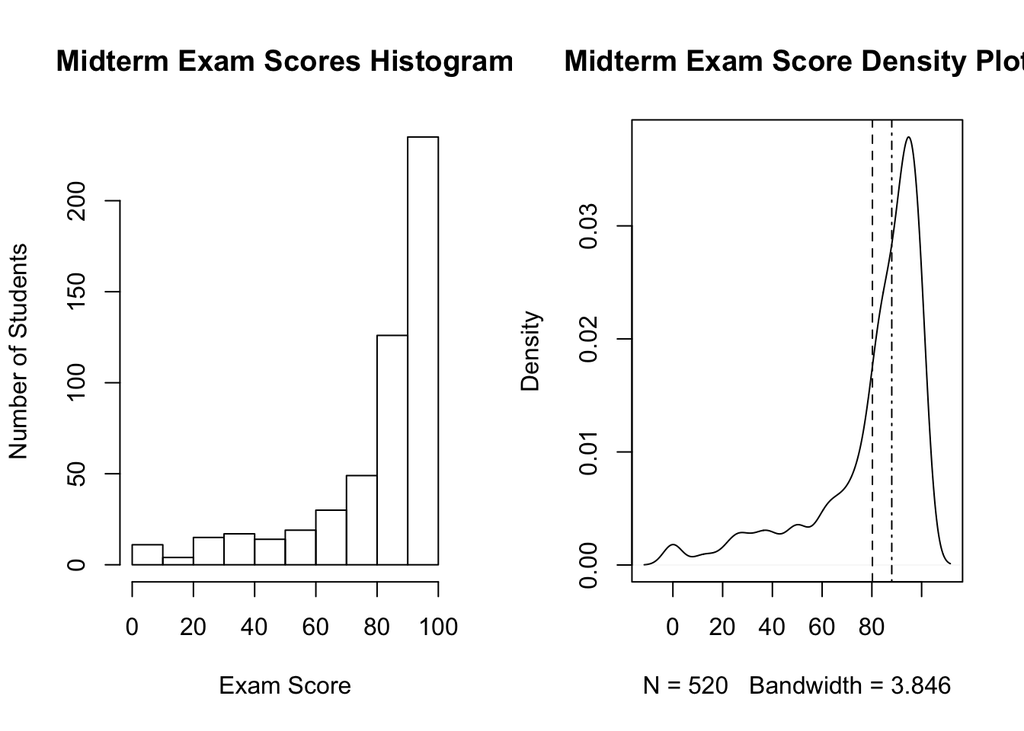

```r
par(mfrow=c(1,2))
hist(midtermGrades, main="Midterm Exam Scores Histogram", xlab="Exam Score", ylab="Number of Students")
d1 <- density(midtermGrades)
plot(d1, main="Midterm Exam Score Density Plot")
abline(v=c(mean(midtermGrades), median(midtermGrades)), lty=c(2,4))
```

Q13(5pts): Do the same as above for the FinalExam distribution.

[figure not shown]

```r
par(mfrow=c(1,2))
hist(df.grades$FinalExam, main="Midterm Exam Scores Histogram", xlab="Exam Score", ylab="Number of Students")
d2 <- density(df.grades$FinalExam)
plot(d2, main="Final Exam Score Density Plot")
abline(v=c(mean(df.grades$FinalExam), median(df.grades$FinalExam)), lty=c(2,4))
```

Q14(5pts): Now create a plot with all four graphs: on the first row display the histogram and density for the midterm, and on the bottom row display the same for the final exam.

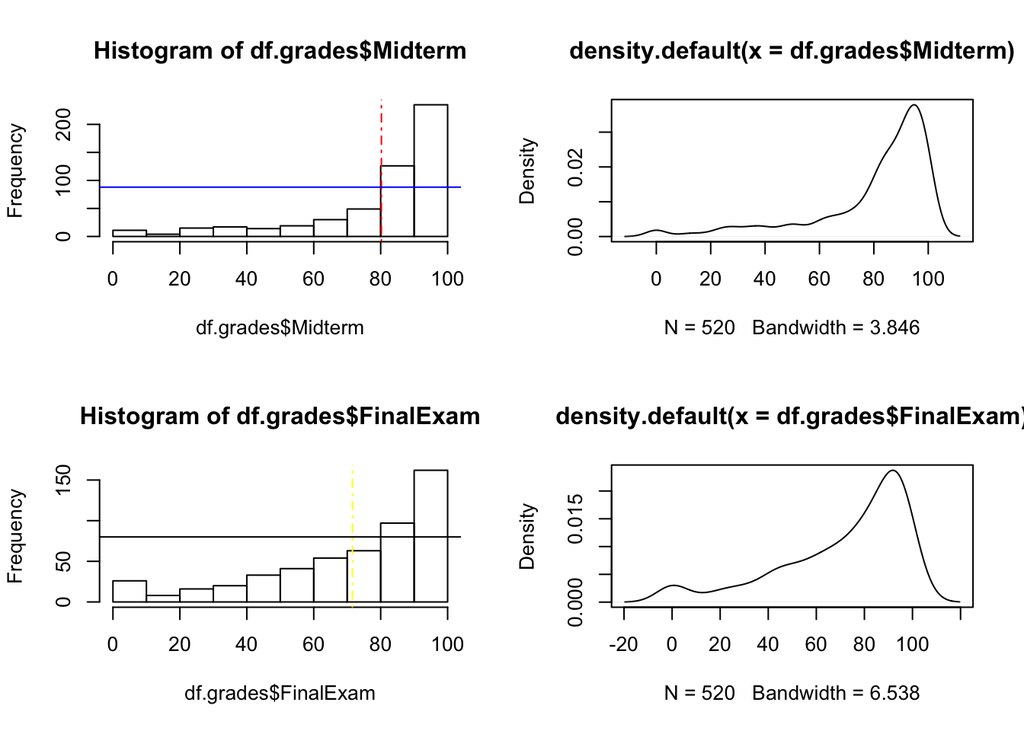

```r
par(mfrow=c(2,2))
hist(df.grades$Midterm)
abline(v=mean(df.grades$Midterm), col=10, lty=4)
abline(h=median(df.grades$Midterm), col=20, lty=1)
plot(density(df.grades$Midterm))
hist(df.grades$FinalExam)
abline(v=mean(df.grades$FinalExam), col=15, lty=4)
abline(h=median(df.grades$FinalExam), col=25, lty=1)
plot(density(df.grades$FinalExam))
```

The following code displays a histogram overlayed with a density plot. You want the histogram to show probability instead of frequency counts because that will match the desity.

```r
hist(df.grades$Midterm, prob=TRUE, main="Midterm Grades", xlab="grade")
abline(v=mean(df.grades$Midterm), lty=2)
abline(v=median(df.grades$Midterm), lty=3)
lines(density(df.grades$Midterm))
```

[output not shown]

Q15(5pts): Write the R code that produces the same plot as above but for the final exam.

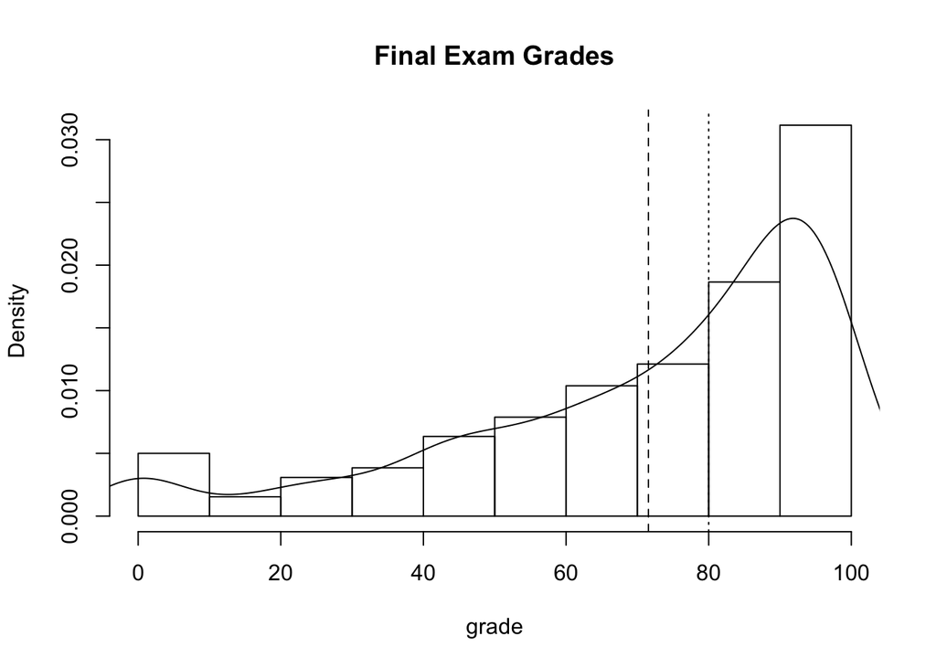

```r
hist(df.grades$FinalExam, prob=TRUE, main="Final Exam Grades", xlab="grade")
abline(v=mean(df.grades$FinalExam), lty=2)
abline(v=median(df.grades$FinalExam), lty=3)
lines(density(df.grades$FinalExam))
```

Q16(5pts): Write code that displays the above plots side by side in one row, midterm on the left, final exam on the right.

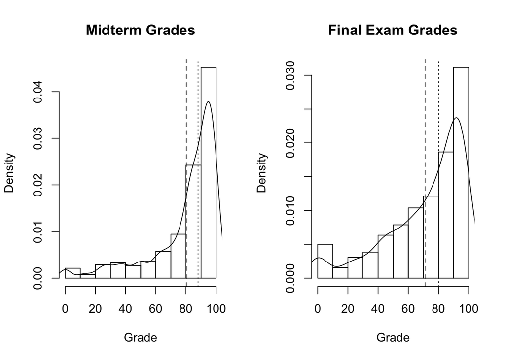

```r
# graphical parameter for multiple plots
par(mfrow=c(1,2))
hist(df.grades$Midterm, prob=TRUE, main="Midterm Grades", xlab="Grade")
abline(v=mean(df.grades$Midterm), lty=2)
abline(v=median(df.grades$Midterm), lty=3)
lines(density(df.grades$Midterm))
hist(df.grades$FinalExam, prob=TRUE, main="Final Exam Grades", xlab="Grade")
abline(v=mean(df.grades$FinalExam), lty=2)
abline(v=median(df.grades$FinalExam), lty=3)
lines(density(df.grades$FinalExam))
```

Q17(5pts): Now generate box plots of the midterm final exam grades. Display both box plots in one plot (i.e. one call to boxplot). Use a sequence (see previous hwk) to specify the columns. Add the title: “Midterm and Final Exam Distributions”.

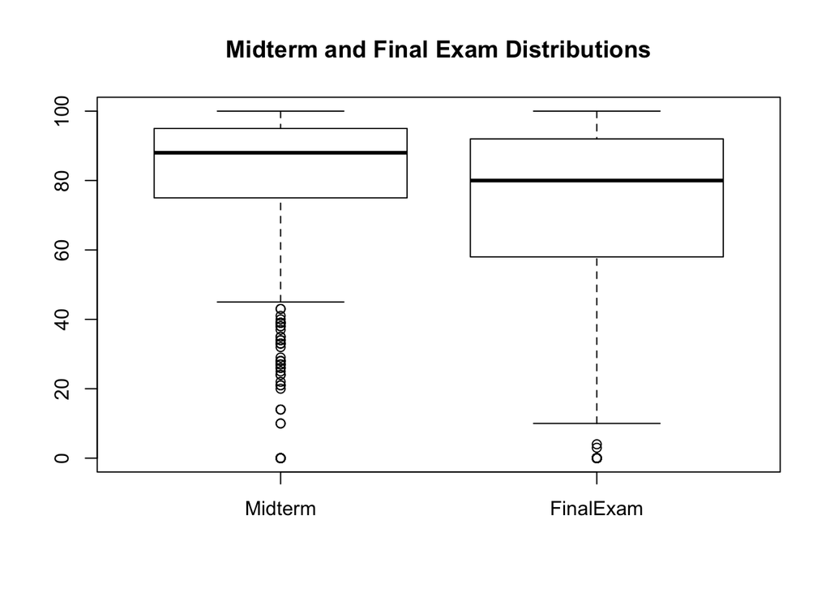

```r
par(mfrow=c(1,1))
boxplot(df.grades[,1:2], df.grades$Midterm~df.grades$FinalExam, main="Midterm and Final Exam Distributions")
```